# Tarspot_analysis

## Alpha Diversity

Let’s check the alpha diversity of species within each lesion type using Shannon’s index

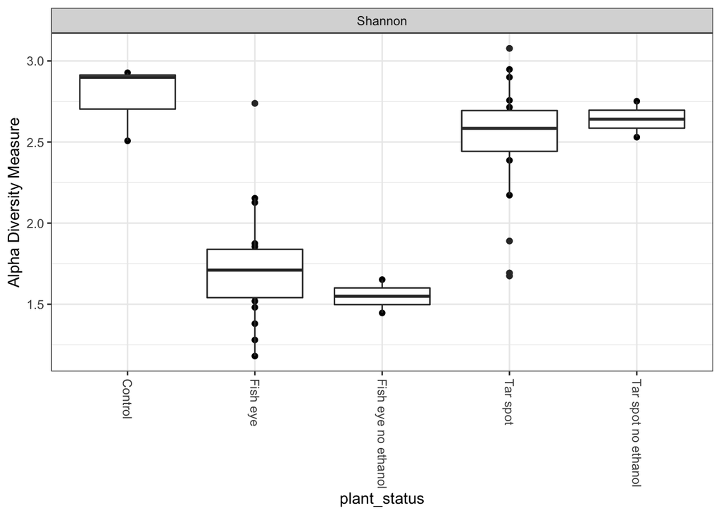

```r
theme_set(theme_bw())
p <- plot_richness(tarspot_physeq, x="plant_status", measures="Shannon") +
  geom_boxplot()
p
```

Using the full dataset (tarspot_physeq) and the pruned dataset (tarspot_pruned) yield very similar plots. They show that the Control and tar spot samples seem to have higher diversity measurements. Perhaps the lack of diversity among Fish eye samples is due to a higher abundance of necrotic tissues that make it harder for most species to survive and thrive here.

Since the “no ethanol” controls match their respective lesion types, merge them in with their lesion typs and re-run the diversity plot

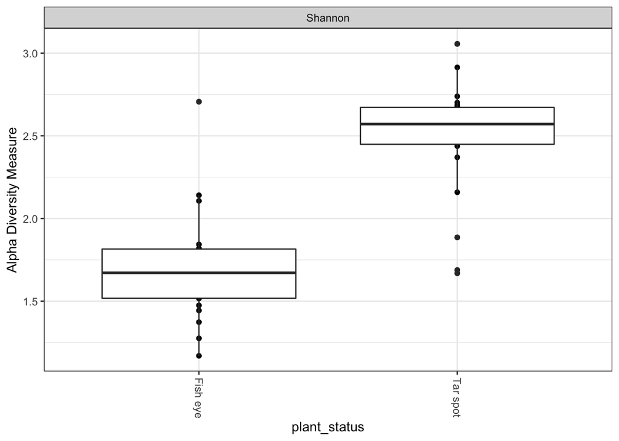

```r
alpha <- tarspot_pruned
alpha@sam_data$plant_status <- as.character(alpha@sam_data$plant_status)
alpha@sam_data$plant_status[alpha@sam_data$plant_status=="Tar spot no ethanol"] <- "Tar spot"
alpha@sam_data$plant_status[alpha@sam_data$plant_status=="Fish eye no ethanol"] <- "Fish eye"
alpha@sam_data$plant_status[alpha@sam_data$plant_status=="Control"] <- "No symptoms"
alpha@sam_data$plant_status <- as.factor(alpha@sam_data$plant_status)
#Per reviewer request, drop "no symptoms" since they are uneven sample numbers
alpha@sam_data <- alpha@sam_data[alpha@sam_data$plant_status!="No symptoms",]
alpha@otu_table <- alpha@otu_table[,-c(45:47)]
#alpha@sam_data$plant_status <- relevel(alpha@sam_data$plant_status, "No symptoms")
p <- plot_richness(alpha, x="plant_status", measures="Shannon") +
  geom_boxplot()
p
```

Again, the full dataset and the pruned dataset yield very similar plots. The Shannon index still shows interesting differences between Fish eye symptoms and the others, so let’s take a look at “richness” and “evenness”, which are both parts of the Shannon index calculation. This idea / code is largely taken from: https://github.com/joey711/phyloseq/issues/945

```r
tarspot_physeq_disease <- tarspot_physeq
tarspot_physeq_disease@otu_table <- tarspot_physeq_disease@otu_table[,-c(45:47)]
alpha_diversity <- estimate_richness(tarspot_physeq_disease, measure = c("Shannon", "Observed"))
H <- alpha_diversity$Shannon
S1 <- alpha_diversity$Observed
S <- log(S1)
evenness <- H/S
alpha_diversity$Evenness = evenness
#Again, merge the "no ethanol" controls with their respective symptoms
tarspot_meta$plant_status <- as.character(tarspot_meta$plant_status)
tarspot_meta$plant_status[tarspot_meta$plant_status=="Tar spot no ethanol"] <- "Tar spot"
tarspot_meta$plant_status[tarspot_meta$plant_status=="Fish eye no ethanol"] <- "Fish eye"
tarspot_meta$plant_status[tarspot_meta$plant_status=="Control"] <- "No symptoms"
tarspot_meta$plant_status <- as.factor(tarspot_meta$plant_status)
#Per reviewer request, drop "no symptoms" since they are uneven sample numbers
tarspot_meta <- tarspot_meta[tarspot_meta$plant_status!="No symptoms",]
tarspot_meta$plant_status <- droplevels(tarspot_meta$plant_status, "No symptoms")

#Make sure alpha_diversity file is in same order as the meta file so that it can be appended
alpha_diversity <- alpha_diversity[order(row.names(alpha_diversity)),]
#Sanity check
identical(rownames(alpha_diversity), rownames(tarspot_meta))
```

```
## [1] TRUE
```

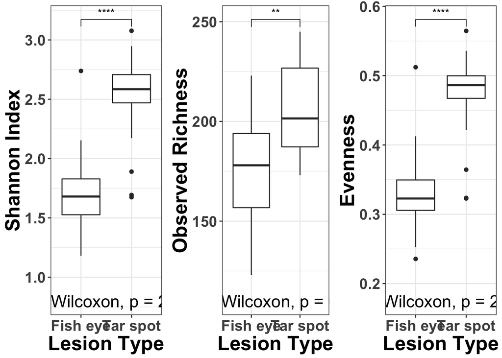

```r
#Append the shannon data onto the metadata file
tarspot_meta$Shannon <- alpha_diversity$Shannon
tarspot_meta$Observed <- alpha_diversity$Observed
tarspot_meta$Evenness <- alpha_diversity$Evenness
PY <- levels(tarspot_meta$plant_status)
PY.pairs <- combn(seq_along(PY), 2, simplify = FALSE, FUN = function(i)PY[i])

pS <- ggplot(data=tarspot_meta, aes_string(x='plant_status', y='Shannon')) +
  geom_boxplot() +
  ylab("Shannon Index") + xlab("Lesion Type") +
  theme(axis.title.x = element_text(face="bold", size = 20),
        axis.title.y = element_text(face="bold", size = 20),
        axis.text = element_text(face="bold", size = 15)) +
  stat_compare_means(comparisons = PY.pairs, label = "p.signif") +
  stat_compare_means(label.y = 0.8, size = 6)

pO <- ggplot(data=tarspot_meta, aes_string(x='plant_status', y='Observed')) +
  geom_boxplot() +
  ylab("Observed Richness") + xlab("Lesion Type") +
  theme(axis.title.x = element_text(face="bold", size = 20),
        axis.title.y = element_text(face="bold", size = 20),
        axis.text = element_text(face="bold", size = 15)) +
  stat_compare_means(comparisons = PY.pairs, label = "p.signif") +
  stat_compare_means(label.y = 110, size = 6)

pE <- ggplot(data=tarspot_meta, aes_string(x='plant_status', y='Evenness')) +
  geom_boxplot() +
  ylab("Evenness") + xlab("Lesion Type") +
  theme(axis.title.x = element_text(face="bold", size = 20),
        axis.title.y = element_text(face="bold", size = 20),
        axis.text = element_text(face="bold", size = 15)) +
  stat_compare_means(comparisons = PY.pairs, label = "p.signif",
                     label.y.npc = "bottom") +
  stat_compare_means(label.y = 0.175, size = 6)

grid.arrange(pS, pO, pE, ncol = 3)
```

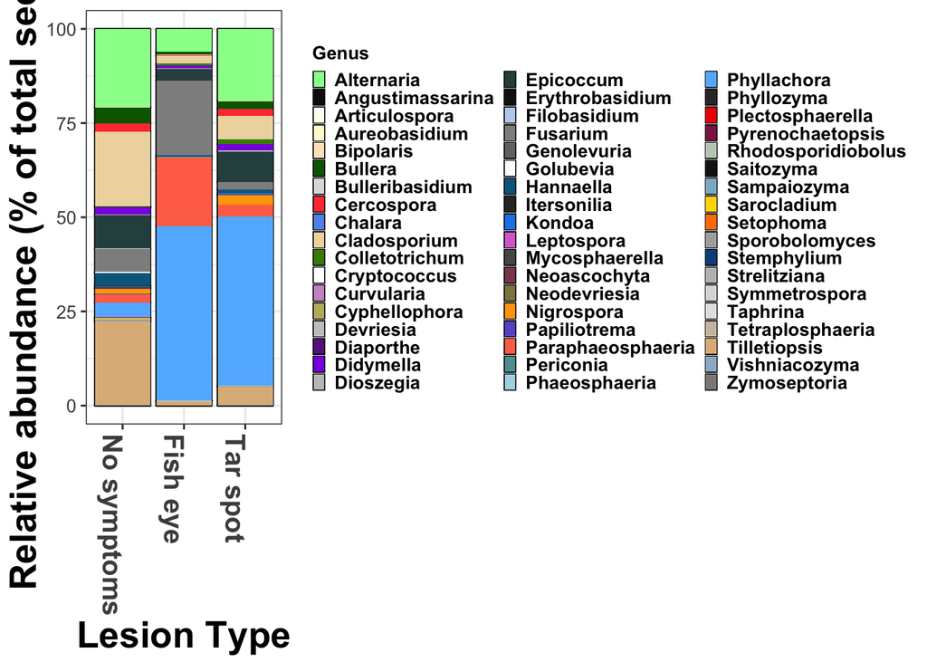

```r
#Bar charts by taxonomy level
#Merge the "no ethanol" controls in with their lesion type
pooled_pruned <- tarspot_pruned
pooled_pruned@sam_data$plant_status <- as.character(pooled_pruned@sam_data$plant_status)
pooled_pruned@sam_data$plant_status[pooled_pruned@sam_data$plant_status=="Tar spot no ethanol"] <- "Tar spot"
pooled_pruned@sam_data$plant_status[pooled_pruned@sam_data$plant_status=="Fish eye no ethanol"] <- "Fish eye"
pooled_pruned@sam_data$plant_status[pooled_pruned@sam_data$plant_status=="Control"] <- "No symptoms"
pooled_pruned@sam_data$plant_status <- as.factor(pooled_pruned@sam_data$plant_status)
pooled_pruned@sam_data$plant_status <- relevel(pooled_pruned@sam_data$plant_status, "No symptoms")

#merge samples
pooled_pruned_merge <- merge_samples(pooled_pruned, "plant_status")
sample_data(pooled_pruned_merge)$plant_status <- factor(sample_names(pooled_pruned_merge))
#taxa merge
pooled_pruned_merge <- tax_glom(pooled_pruned_merge, "Genus")
##Transform to percentage of total available
pooled_pruned_merge = transform_sample_counts(pooled_pruned_merge, function(x) 100 * x/sum(x))
#Relevel plant_status
pooled_pruned_merge@sam_data$plant_status <- relevel(pooled_pruned_merge@sam_data$plant_status,"No symptoms")
#generate stacked bar plot
cl <- colors(distinct = TRUE)
set.seed(44)
mycols <- sample(cl,60)
p1 <- plot_bar(pooled_pruned_merge, fill = 'Genus', x = 'plant_status') +
  xlab("Lesion Type") +
  theme(axis.title.x = element_text(face="bold", size = 20),
        axis.text.x = element_text(face="bold", size=15, angle = 270),
        axis.title.y = element_text(face="bold", size = 20),
        axis.text.y = element_text(size = 10),
        legend.title = element_text(face="bold", size = 10),
        legend.text = element_text(face="bold", size = 10),
        legend.key.size = unit(0.5, 'lines'),
        legend.position = "right") +
  scale_y_continuous(labels=function(n){format(n, scientific = FALSE)})+
  geom_bar(aes(fill = Genus ), stat = 'identity', position = 'stack') +
  scale_fill_manual(values= mycols) +
  ylab("Relative abundance (% of total sequences)")

p1
```

Let’s see if the communities for each type of lesion are different by running a PERMANOVA on the distance matrix, as a function of lesion type.

```r
tarspot_physeq@sam_data$plant_status <- as.character(tarspot_physeq@sam_data$plant_status)
tarspot_physeq@sam_data$plant_status[tarspot_physeq@sam_data$plant_status=="Tar spot no ethanol"] <- "Tar spot"
tarspot_physeq@sam_data$plant_status[tarspot_physeq@sam_data$plant_status=="Fish eye no ethanol"] <- "Fish eye"
#tarspot_physeq@sam_data$plant_status[tarspot_physeq@sam_data$plant_status=="Control"] <- "No symptoms"
tarspot_physeq@sam_data$plant_status <- as.factor(tarspot_physeq@sam_data$plant_status)
#Per reviewer request, drop "no symptoms" since they are uneven sample numbers
tarspot_physeq <- subset_samples(tarspot_physeq,
                                 plant_status != "Control")
#tarspot_physeq@sam_data <- tarspot_physeq@sam_data[tarspot_physeq@sam_data$plant_status!="Control"]
#tarspot_physeq@otu_table <- tarspot_physeq@otu_table[,-c(45:47)]
#tarspot_physeq@sam_data$plant_status <- relevel(tarspot_physeq@sam_data$plant_status, "No symptoms")
#Calculate distance matrix
tarspot_dist <- phyloseq::distance(tarspot_physeq, method = "bray")
#Create a list of lesion types
lesion_type <- tarspot_physeq@sam_data$plant_status
#Run PERMNAOVA
p.hoc1 <- adonis(tarspot_dist ~ lesion_type)
#Post hoc test for PERMANOVA
p.hoc2 <- betadisper(tarspot_dist, lesion_type)
#TukeyHSD(p.hoc1)
TukeyHSD(p.hoc2)
```

```
##   Tukey multiple comparisons of means
##     95% family-wise confidence level
##
## Fit: aov(formula = distances ~ group, data = df)
##
## $group
##                         diff        lwr         upr     p adj
## Tar spot-Fish eye -0.1297946 -0.2025913 -0.05699786 0.0008382
```

## Ordination plots

Since this is a large dataset, it helps to look at the data with ordination methods, calculated by different distance metrics. So, let’s generate a PCoA plot to visualize these communities. Let’s use bray-curtis distances, as these are commonly used in ecological data. Since we’ll want to explore taxa associated with each lesion type, we’ll have to use the pruned dataset, or else the plots get too messy.

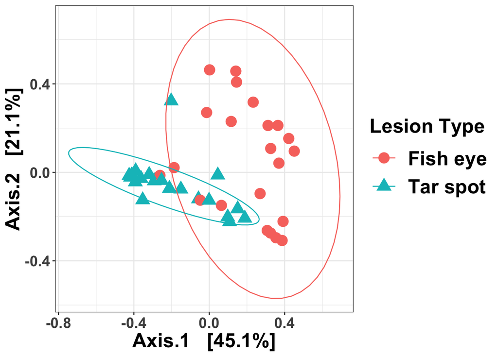

```r
#Per reviewer request, drop "no symptoms"
pooled_pruned <- subset_samples(pooled_pruned,
                                 plant_status != "No symptoms")
#Calculate distance matrix
tarspot_ord_bray <- ordinate(pooled_pruned, "PCoA", "bray")
#PCoA plot

p2 <- plot_ordination(pooled_pruned, tarspot_ord_bray,
                     type="sample", color="plant_status", shape="plant_status") +
  geom_point(size=5) +
  stat_ellipse(level = 0.95) +
  scale_shape_discrete(name="Lesion Type") +
  scale_color_discrete(name="Lesion Type") +
  theme(axis.title.x = element_text(face="bold", size = 20),
        axis.title.y = element_text(face="bold", size = 20),
        axis.text = element_text(face="bold", size = 15),
        legend.title = element_text(face="bold", size = 20),
        legend.text = element_text(face="bold", size = 20),
        legend.key.size = unit(2, 'lines'))

p2
```

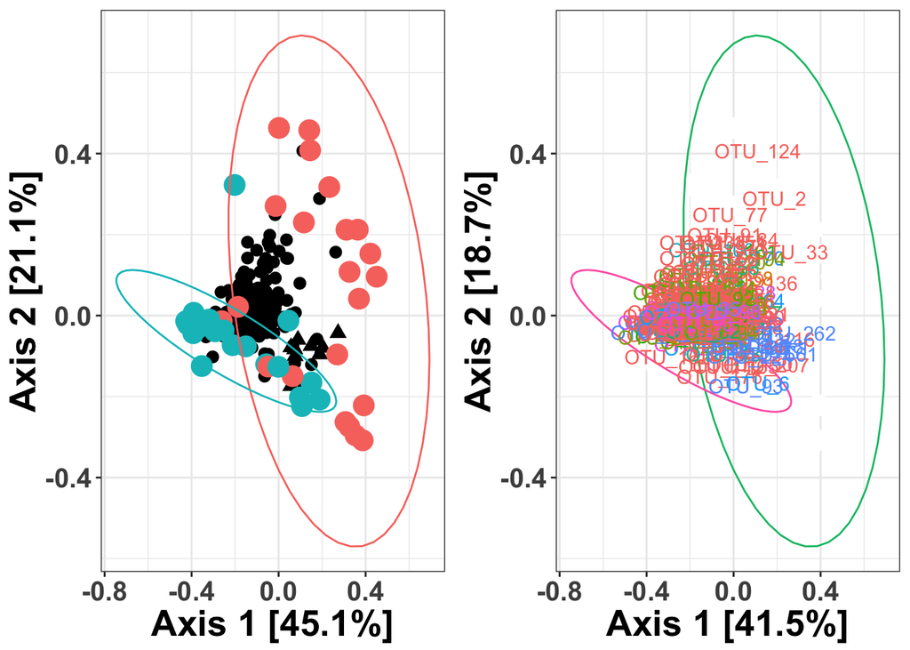

```r
tarspot_ord_bray <- ordinate(pooled_pruned, "PCoA", "bray")
#pooled_pruned@sam_data$plant_status <- ordered(pooled_pruned@sam_data$plant_status,
#                           levels = c("Healthy", "Fish eye", "Tar spot", "Taxa"))
pOTU <- plot_ordination(pooled_pruned, tarspot_ord_bray,
                     type="taxa",
                     color="Phylum",
                     justDF = T)
pOTU$OTU <- rownames(pOTU)

for (i in seq_along(pOTU$OTU)){
  if (pOTU[i,8] == "Phyllachora"){
    pOTU[i,11] <- c("Phyllachora")
  }
#  else if (pOTU[i,8] == "Monographella"){
#    pOTU[i,11] <- c("Microdochium")
#  }
#  else if (pOTU[i,8] == "Microdochium"){
#    pOTU[i,11] <- "Microdochium"
#  }
  else {
    pOTU[i,11] <- "NA"
  }
}

pSample <- plot_ordination(pooled_pruned, tarspot_ord_bray,
                     type="sample",
                     shape="plant_status",
                     color="plant_status",
                     justDF = T)



#pSample$plant_status <- ordered(pSample$plant_status,
#                           levels = c("Healthy", "Fish eye", "Tar spot"))

p4 <- ggplot() +
  geom_point(data = pOTU, size = 3, aes(x=Axis.1, y=Axis.2, shape = V11)) +
  geom_point(data = pSample, size = 5,
             aes(x=Axis.1, y=Axis.2,
                color = plant_status)) +
  stat_ellipse(data = pSample, aes(x=Axis.1, y=Axis.2, color = plant_status),
               level = 0.95) +
  scale_shape_discrete(name="Lesion Type") +
  scale_color_discrete(name="Lesion Type") +
  xlab("Axis 1 [45.1%]") + ylab("Axis 2 [21.1%]") +
  theme(axis.title.x = element_text(face="bold", size = 20),
        axis.title.y = element_text(face="bold", size = 20),
        axis.text = element_text(face="bold", size = 15),
        #legend.title = element_text(face="bold", size = 20),
        #legend.text = element_text(face="bold", size = 20),
        #legend.key.size = unit(2, 'lines')
        legend.position=""
        )
#p4

p5 <- ggplot() +
  geom_point(data = pOTU, color = "white", aes(x=Axis.1, y=Axis.2)) +
  geom_point(data = pSample, size = 5, color = "white",
             aes(x=Axis.1, y=Axis.2)) +
  stat_ellipse(data = pSample, aes(x=Axis.1, y=Axis.2, color = plant_status),
               level = 0.95) +
  scale_shape_discrete(name="Lesion Type") +
  scale_color_discrete(name="Lesion Type") +
  geom_text(data = pOTU, aes(x=Axis.1, y=Axis.2, label=OTU, color = Genus)) +
  xlab("Axis 1 [41.5%]") + ylab("Axis 2 [18.7%]") +
  #xlim(-0.4,0.4) +
  #ylim(-0.2,0.4) +
  theme(axis.title.x = element_text(face="bold", size = 20),
        axis.title.y = element_text(face="bold", size = 20),
        axis.text = element_text(face="bold", size = 15),
        #legend.title = element_text(face="bold", size = 20),
        #legend.text = element_text(face="bold", size = 20),
        #legend.key.size = unit(2, 'lines')
        legend.position="none"
        )

#p5
grid.arrange(p4,p5, ncol = 2)
```

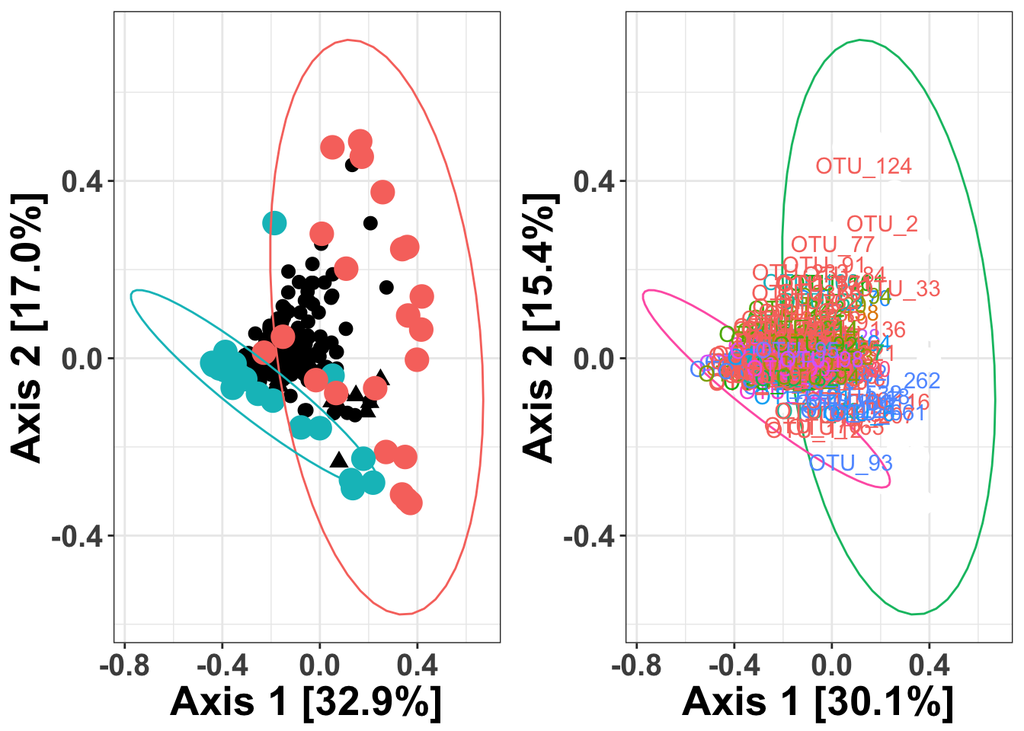

```r
tarspot_ord_jac <- ordinate(pooled_pruned, "PCoA", "jaccard")
pooled_pruned@sam_data$plant_status <- ordered(pooled_pruned@sam_data$plant_status,
                           levels = c("Healthy", "Fish eye", "Tar spot", "Taxa"))
pOTU_jac <- plot_ordination(pooled_pruned, tarspot_ord_jac,
                     type="taxa",
                     color="Phylum",
                     justDF = T)
pOTU_jac$OTU <- rownames(pOTU_jac)
pSample_jac <- plot_ordination(pooled_pruned, tarspot_ord_jac,
                     type="sample",
                     shape="plant_status",
                     color="plant_status",
                     justDF = T)
pSample_jac$plant_status <- ordered(pSample_jac$plant_status,
                           levels = c("Healthy", "Fish eye", "Tar spot"))
for (i in seq_along(pOTU_jac$OTU)){
  if (pOTU_jac[i,8] == "Phyllachora"){
    pOTU_jac[i,11] <- c("Phyllachora")
  }
#  else if (pOTU_jac[i,8] == "Monographella"){
#    pOTU_jac[i,11] <- c("Microdochium")
#  }
#  else if (pOTU_jac[i,8] == "Microdochium"){
#    pOTU_jac[i,11] <- "Microdochium"
#  }
  else {
    pOTU_jac[i,11] <- "NA"
  }
}

#pOTU_jac$Axis.1 <- pOTU_jac$Axis.1 * -1
#pSample_jac$Axis.1 <- pSample_jac$Axis.1 * -1
p6 <- ggplot() +
  geom_point(data = pOTU_jac, size = 3, aes(x=Axis.1, y=Axis.2, shape = V11)) +
  geom_point(data = pSample_jac, size = 5,
             aes(x=Axis.1, y=Axis.2,
                color = plant_status)) +
  stat_ellipse(data = pSample_jac, aes(x=Axis.1, y=Axis.2, color = plant_status),
               level = 0.95) +
  scale_shape_discrete(name="Lesion Type") +
  scale_color_discrete(name="Lesion Type") +
  xlab("Axis 1 [32.9%]") + ylab("Axis 2 [17.0%]") +
  theme(axis.title.x = element_text(face="bold", size = 20),
        axis.title.y = element_text(face="bold", size = 20),
        axis.text = element_text(face="bold", size = 15),
        #legend.title = element_text(face="bold", size = 20),
        #legend.text = element_text(face="bold", size = 20),
        #legend.key.size = unit(2, 'lines')
        legend.position="none"
        )
#p6

p7 <- ggplot() +
  geom_point(data = pOTU_jac, color = "white", aes(x=Axis.1, y=Axis.2)) +
  geom_point(data = pSample_jac, size = 5, color = "white",
             aes(x=Axis.1, y=Axis.2)) +
  stat_ellipse(data = pSample_jac, aes(x=Axis.1, y=Axis.2, color = plant_status),
               level = 0.95) +
  scale_shape_discrete(name="Lesion Type") +
  scale_color_discrete(name="Lesion Type") +
  geom_text(data = pOTU_jac, aes(x=Axis.1, y=Axis.2, label=OTU, color = Genus)) +
  xlab("Axis 1 [30.1%]") + ylab("Axis 2 [15.4%]") +
  #xlim(-0.2,0.2) +
  #ylim(0.,0.3) +
  theme(axis.title.x = element_text(face="bold", size = 20),
        axis.title.y = element_text(face="bold", size = 20),
        axis.text = element_text(face="bold", size = 15),
        #legend.title = element_text(face="bold", size = 20),
        #legend.text = element_text(face="bold", size = 20),
        #legend.key.size = unit(2, 'lines')
        legend.position="none")

#p7
grid.arrange(p6,p7, ncol = 2)
```

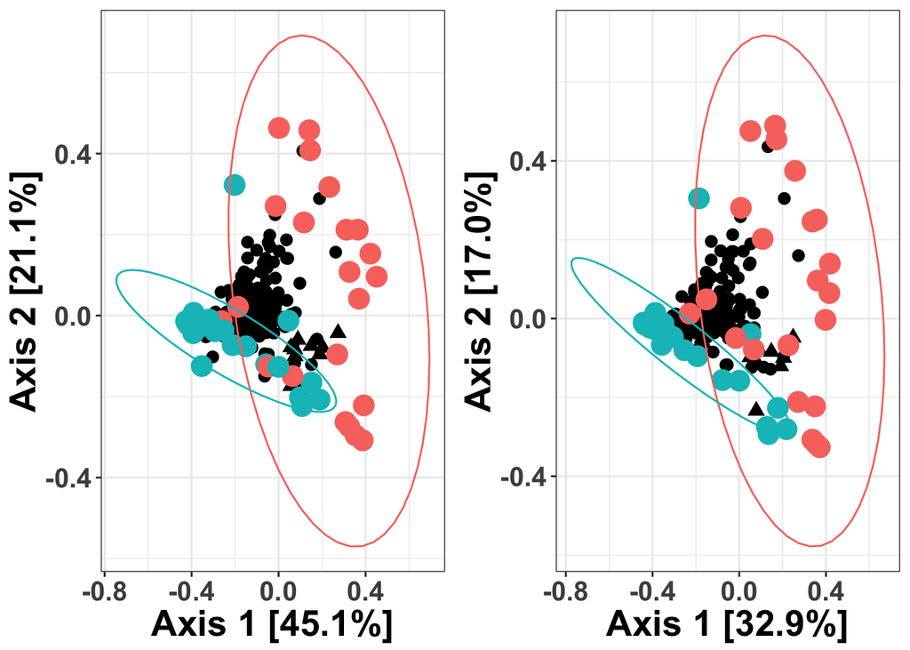

```r
grid.arrange(p4,p6, ncol = 2)
```

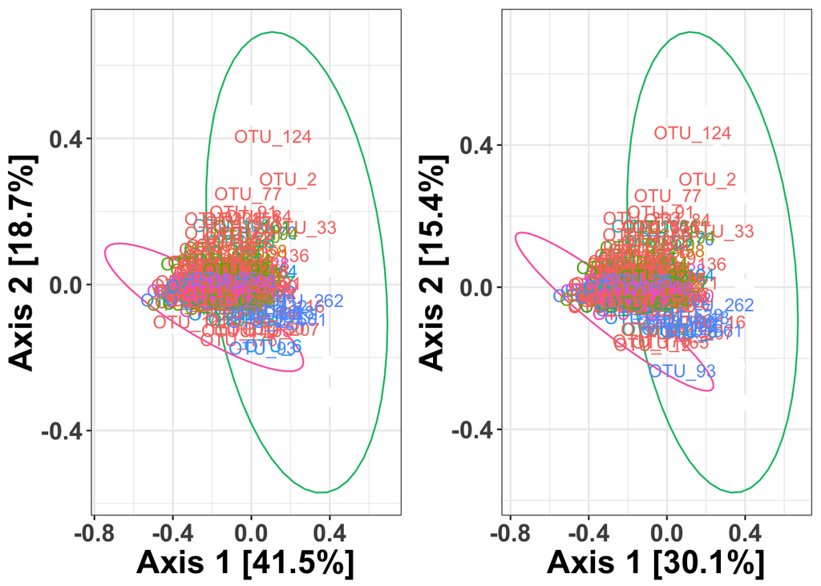

```r
grid.arrange(p5,p7, ncol = 2)
```

Neat! So now we can see that there are specific OTUs associated with Fish eye lesions, perhaps driving the symptoms we see. Let’s find ou what some of these are. Also, Bray and Jaccard results are almost identical, suggesting that the separation of lesion types are driven by presence/absence data, but abundance may still be playing a role.

```r
#Use this code to find ID of candidate OTUs by replacing "OTU_" with the OTU of interest
pOTU[pOTU$OTU=="OTU_214",]
```

```
##  [1] Axis.1  Axis.2  Kingdom Phylum  Class   Order   Family  Genus
##  [9] Species OTU     V11
## <0 rows> (or 0-length row.names)
```

```r
tarspot_physeq@tax_table[rownames(tarspot_physeq@tax_table)=="OTU_2",]
```

```
## Taxonomy Table:     [1 taxa by 7 taxonomic ranks]:
##       Kingdom Phylum Class Order Family Genus Species
## OTU_2 "Fungi" ""     ""    ""    ""     ""    ""
```

### Indicator species analysis

```r
#Per reviewer request, dropped "control" samples from analysis
#This caused problems in indicator species analysis, as some OTUs were ONLY identified in control samples. Therefore, during indicator species analysis, these OTU's get NA values rather than 0 or 1.
#Manually identified that there are 23 OTUs that were ONLY identified in control samples.
#Manually remove them prior to indicator species analysis
cut_taxa <- c("OTU_294","OTU_352","OTU_472","OTU_490","OTU_244",
              "OTU_523","OTU_645","OTU_476","OTU_666","OTU_621",
              "OTU_384","OTU_622","OTU_380","OTU_561","OTU_605",
              "OTU_575","OTU_452","OTU_703","OTU_534","OTU_546",
              "OTU_578","OTU_712","OTU_554")
keep_taxa <- NULL
for(i in 1:nrow(tarspot_physeq@otu_table)){
  if(as.character(rownames(tarspot_physeq@otu_table[i])) %in% cut_taxa){}
  else{
    keep_taxa[i] <- as.character(rownames(tarspot_physeq@otu_table[i]))
  }
}
#sanity check
'OTU_1' %in% keep_taxa    #TRUE
```

```
## [1] TRUE
```

```r
'OTU_294' %in% keep_taxa  #FALSE
```

```
## [1] FALSE
```

```r
#Prune these taxa out
tarspot_physeq_ind <- prune_taxa(keep_taxa, tarspot_physeq)
'OTU_1' %in% rownames(tarspot_physeq_ind@otu_table)    #TRUE
```

```
## [1] TRUE
```

```r
'OTU_294' %in% rownames(tarspot_physeq_ind@otu_table)  #FALSE
```

```
## [1] FALSE
```

```r
#Normalize reads
tarspot_physeq@otu_table
```

[output not shown]

[output cut: 4363 more lines]

[output not shown]

```r
tarspot_physeq_norm <- transform_sample_counts(tarspot_physeq_ind, function(x) x/sum(x))
tarspot_physeq_norm@otu_table
```

[output not shown]

[output cut: 6364 more lines]

[output not shown]

```r
##############################################################
# WARNING - 100 iterations will take some time, and significant
# computaitonal power. I can run this on my laptop, but it's
# not happy by the end of it. Recommended changing 100 to 10
# if you're just testing the code
##############################################################
indicator.tar <- indicspecies::multipatt(as.data.frame(t(tarspot_physeq_norm@otu_table)), cluster = tarspot_physeq_norm@sam_data$plant_status, duleg = T, control = how(nperm=999))
summary(indicator.tar, alpha = 0.05)
```

```
##
##  Multilevel pattern analysis
##  ---------------------------
##
##  Association function: IndVal.g
##  Significance level (alpha): 0.05
##
##  Total number of species: 712
##  Selected number of species: 91
##  Number of species associated to 1 group: 91
##
##  List of species associated to each combination:
##
##  Group Fish eye  #sps.  10
##          stat p.value
## OTU_7   0.967   0.017 *
## OTU_2   0.961   0.002 **
## OTU_6   0.946   0.034 *
## OTU_262 0.926   0.017 *
## OTU_33  0.912   0.001 ***
## OTU_147 0.652   0.043 *
## OTU_466 0.603   0.005 **
## OTU_288 0.590   0.030 *
## OTU_249 0.510   0.033 *
## OTU_312 0.508   0.036 *
##
##  Group Tar spot  #sps.  81
##          stat p.value
## OTU_34  0.961   0.001 ***
## OTU_134 0.955   0.001 ***
## OTU_652 0.944   0.001 ***
## OTU_4   0.941   0.001 ***
## OTU_10  0.941   0.001 ***
## OTU_97  0.923   0.001 ***
## OTU_44  0.912   0.005 **
## OTU_23  0.912   0.001 ***
## OTU_3   0.911   0.001 ***
## OTU_72  0.906   0.005 **
## OTU_8   0.906   0.001 ***
## OTU_41  0.897   0.001 ***
```

[output cut: 56 more lines]

```
## OTU_527 0.603   0.012 *
## OTU_205 0.597   0.031 *
## OTU_432 0.577   0.047 *
## OTU_326 0.564   0.010 **
## OTU_520 0.541   0.047 *
## OTU_329 0.540   0.021 *
## OTU_665 0.529   0.035 *
## OTU_309 0.521   0.037 *
## OTU_376 0.512   0.036 *
## OTU_267 0.499   0.031 *
## OTU_311 0.477   0.047 *
## OTU_367 0.477   0.043 *
## OTU_373 0.477   0.037 *
## ---
## Signif. codes:  0 '***' 0.001 '**' 0.01 '*' 0.05 '.' 0.1 ' ' 1
```

I got 10 OTUs that were significant

Let’s see what the pruned data file tells us for indicator species

```r
pooled_pruned@sam_data$plant_status
```

```
##  [1] Tar spot Fish eye Fish eye Tar spot Fish eye Tar spot Tar spot
##  [8] Tar spot Fish eye Tar spot Tar spot Fish eye Tar spot Tar spot
## [15] Fish eye Fish eye Tar spot Fish eye Tar spot Fish eye Fish eye
## [22] Tar spot Fish eye Fish eye Tar spot Fish eye Fish eye Fish eye
## [29] Tar spot Fish eye Tar spot Tar spot Fish eye Fish eye Fish eye
## [36] Tar spot Fish eye Tar spot Fish eye Tar spot Tar spot Tar spot
## [43] Fish eye Tar spot
## Levels: Healthy < Fish eye < Tar spot < Taxa
```

```r
pooled_pruned_ind <- pooled_pruned
pooled_pruned_ind <- subset_samples(pooled_pruned,
                                plant_status != "Healthy")
pooled_pruned_ind <- subset_samples(pooled_pruned,
                                plant_status != "Taxa")
for(i in 1:nrow(pooled_pruned_ind@otu_table)){
  if(as.character(rownames(pooled_pruned_ind@otu_table[i])) %in% cut_taxa){}
  else{
    keep_taxa[i] <- as.character(rownames(pooled_pruned_ind@otu_table[i]))
  }
}

#Prune these taxa out
pooled_pruned_ind <- prune_taxa(keep_taxa, pooled_pruned_ind)
'OTU_1' %in% rownames(pooled_pruned_ind@otu_table)    #TRUE
```

```
## [1] TRUE
```

```r
'OTU_294' %in% rownames(pooled_pruned_ind@otu_table)  #FALSE
```

```
## [1] FALSE
```

```r
indicator.tar.prune <- indicspecies::multipatt(as.data.frame(t(pooled_pruned_ind@otu_table)), cluster = pooled_pruned_ind@sam_data$plant_status, duleg = T, control = how(nperm=999))
summary(indicator.tar.prune, alpha = 0.05)
```

```
##
##  Multilevel pattern analysis
##  ---------------------------
##
##  Association function: IndVal.g
##  Significance level (alpha): 0.05
##
##  Total number of species: 218
##  Selected number of species: 71
##  Number of species associated to 1 group: 71
##
##  List of species associated to each combination:
##
##  Group Fish eye  #sps.  5
##          stat p.value
## OTU_7   0.967   0.011 *
## OTU_2   0.961   0.001 ***
## OTU_6   0.945   0.040 *
## OTU_262 0.926   0.011 *
## OTU_33  0.911   0.005 **
##
##  Group Tar spot  #sps.  66
##          stat p.value
## OTU_34  0.961   0.001 ***
## OTU_134 0.955   0.001 ***
## OTU_652 0.945   0.001 ***
## OTU_4   0.942   0.001 ***
## OTU_10  0.942   0.001 ***
## OTU_97  0.923   0.001 ***
## OTU_44  0.912   0.006 **
## OTU_23  0.912   0.001 ***
## OTU_3   0.912   0.001 ***
## OTU_8   0.907   0.001 ***
## OTU_72  0.907   0.005 **
## OTU_41  0.897   0.003 **
## OTU_73  0.892   0.001 ***
## OTU_21  0.892   0.015 *
## OTU_53  0.888   0.001 ***
## OTU_93  0.885   0.008 **
## OTU_450 0.884   0.001 ***
```

[output cut: 36 more lines]

```
## OTU_70  0.781   0.024 *
## OTU_114 0.778   0.018 *
## OTU_133 0.778   0.004 **
## OTU_589 0.777   0.012 *
## OTU_74  0.769   0.027 *
## OTU_121 0.765   0.037 *
## OTU_142 0.759   0.006 **
## OTU_86  0.749   0.021 *
## OTU_503 0.749   0.042 *
## OTU_169 0.742   0.030 *
## OTU_126 0.645   0.018 *
## OTU_155 0.639   0.038 *
## OTU_205 0.597   0.045 *
## ---
## Signif. codes:  0 '***' 0.001 '**' 0.01 '*' 0.05 '.' 0.1 ' ' 1
```

I got 5 OTUs that were significant Let’s see what all of these species actually are.

```r
ind.otu <- as.data.frame(tarspot_physeq@tax_table)
ind.otu$otu <- rownames(ind.otu)
#Taxa in both full and pruned indicator species analysis:
indicator.tax <- ind.otu[ind.otu$otu == "OTU_2",]
indicator.tax[2,] <- ind.otu[ind.otu$otu == "OTU_6",]
indicator.tax[3,] <- ind.otu[ind.otu$otu == "OTU_7",]
indicator.tax[4,] <- ind.otu[ind.otu$otu == "OTU_33",]
indicator.tax[5,] <- ind.otu[ind.otu$otu == "OTU_262",]
indicator.tax[1:5,]
```

```
##         Kingdom     Phylum           Class          Order
## OTU_2     Fungi
## OTU_6     Fungi Ascomycota Dothideomycetes   Pleosporales
## OTU_7     Fungi Ascomycota Sordariomycetes    Hypocreales
## OTU_33    Fungi Ascomycota Dothideomycetes
## OTU_262   Fungi Ascomycota Sordariomycetes Phyllachorales
##                     Family             Genus            Species     otu
## OTU_2                                                             OTU_2
## OTU_6   Didymosphaeriaceae Paraphaeosphaeria                      OTU_6
## OTU_7          Nectriaceae          Fusarium                      OTU_7
## OTU_33                                                           OTU_33
## OTU_262    Phyllachoraceae       Phyllachora Phyllachora maydis OTU_262
```

```r
#Taxa in full indicator species analysis onlhy:
indicator.tax[7,] <- ind.otu[ind.otu$otu == "OTU_214",]
indicator.tax[8,] <- ind.otu[ind.otu$otu == "OTU_249",]
indicator.tax[9,] <- ind.otu[ind.otu$otu == "OTU_288",]
indicator.tax[10,] <- ind.otu[ind.otu$otu == "OTU_312",]
indicator.tax[11,] <- ind.otu[ind.otu$otu == "OTU_347",]
indicator.tax[12,] <- ind.otu[ind.otu$otu == "OTU_466",]
indicator.tax[7:12,]
```

```
##         Kingdom     Phylum           Class        Order             Family
## 7         Fungi Ascomycota Sordariomycetes  Sordariales      Chaetomiaceae
## OTU_249   Fungi Ascomycota Sordariomycetes  Hypocreales        Nectriaceae
## OTU_288   Fungi Ascomycota Dothideomycetes  Capnodiales     Dissoconiaceae
## OTU_312   Fungi Ascomycota Dothideomycetes Pleosporales
## OTU_347   Fungi Ascomycota Dothideomycetes Pleosporales Didymosphaeriaceae
## OTU_466   Fungi Ascomycota Sordariomycetes
##               Genus Species     otu
## 7          Humicola         OTU_214
## OTU_249    Fusarium         OTU_249
## OTU_288 Dissoconium         OTU_288
## OTU_312                     OTU_312
## OTU_347                     OTU_347
## OTU_466                     OTU_466
```

```r
#Find Phyllachora OTUs that might be misclassified in dothidiomycetes
#Two examples...
tarspot_physeq@tax_table[rownames(tarspot_physeq@tax_table)=="OTU_33",]
```

```
## Taxonomy Table:     [1 taxa by 7 taxonomic ranks]:
##        Kingdom Phylum       Class             Order Family Genus Species
## OTU_33 "Fungi" "Ascomycota" "Dothideomycetes" ""    ""     ""    ""
```

```r
tarspot_physeq@tax_table[rownames(tarspot_physeq@tax_table)=="OTU_46",]
```

```
## Taxonomy Table:     [1 taxa by 7 taxonomic ranks]:
##        Kingdom Phylum       Class             Order Family Genus Species
## OTU_46 "Fungi" "Ascomycota" "Dothideomycetes" ""    ""     ""    ""
```

```r
miss.class <- NULL
class(rownames(tarspot_physeq@tax_table[i,]))
```

```
## [1] "character"
```

```r
j <- 0
for (i in 1:nrow(tarspot_physeq@tax_table)){
  if (tarspot_physeq@tax_table[i,3] == "Dothideomycetes"
      &&
      tarspot_physeq@tax_table[i,4] == ""){
    j <- j + 1
    miss.class.OTU <- rownames(tarspot_physeq@tax_table[i,])
    miss.class[j] <- miss.class.OTU
  }
}
miss.class
```

```
##  [1] "OTU_105" "OTU_112" "OTU_114" "OTU_124" "OTU_130" "OTU_172" "OTU_175"
##  [8] "OTU_181" "OTU_203" "OTU_237" "OTU_303" "OTU_315" "OTU_33"  "OTU_345"
## [15] "OTU_389" "OTU_46"  "OTU_461" "OTU_462" "OTU_473" "OTU_603" "OTU_671"
## [22] "OTU_676" "OTU_692" "OTU_97"
```